# Voz Ativa: Respostas até agora

*Atualizado em 2019-01-29 09:54:41*

## Total de respostas de candidaturas

Durante cerca de dois meses os candidatos ao cargo de deputado federal foram contatados para responderem o questionário da Voz Ativa. Nos gráficos seguintes há um sumário do progresso de respostas coletadas através do SurveyMonkey.

Cerca de 14% dos candidatos dos quais a plataforma conseguiu contactar respondeu o questionário. Com divulgações efetivas em plataformas e redes sociais a adesão dos candidatos à plataforma continuou crescente até o dia das eleições.

| Número | Valor |
| --- | --- |
| Total de candidaturas | 8563 |
| Conseguimos email | 5796 (67.7%) |
| Responderam | 828 (14.3%) |

Entre os eleitos, temos bem menos candidaturas que responderam.

| Número | Valor |
| --- | --- |
| Total de eleitos | 513 |
| Temos email | 414 (80.7%) |
| Responderam | 19 (3.7%) |
| Tem informações na câmara | 241 (47.0%) |

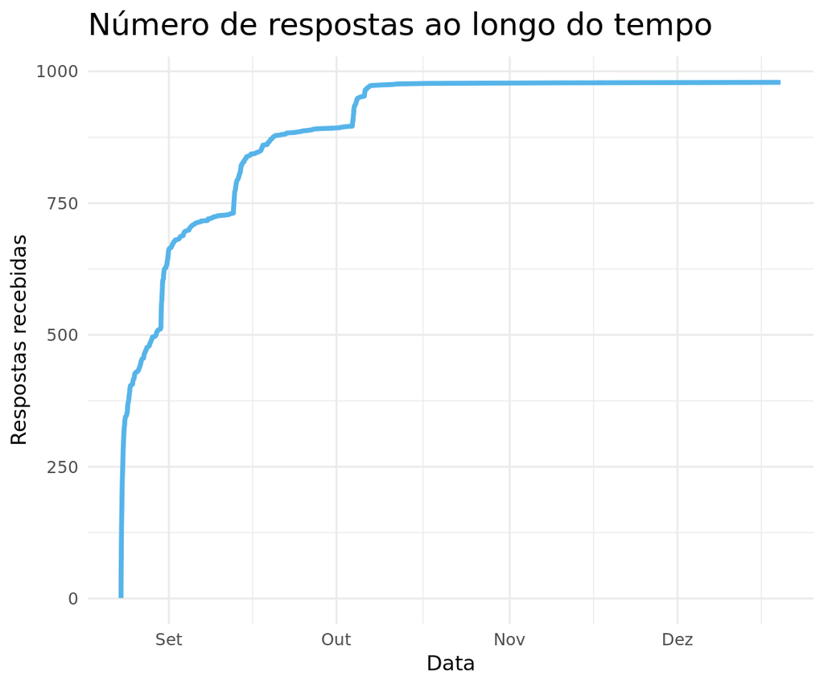

### Por estado

Analisando nosso progresso num contexto de estado vemos a questão de respostas percentuais e absolutas para candidatos em geral e candidatos eleitos. Na visão geral, São Paulo foi o estado onde obtivemos maior sucesso percentual e em nenhum estado não obtivemos respostas. O Espírito Santo, décimo segundo com o maior percentual de respostas, foi o estado com maior proporção de candidatos eleitos e que responderam a plataforma Voz Ativa.

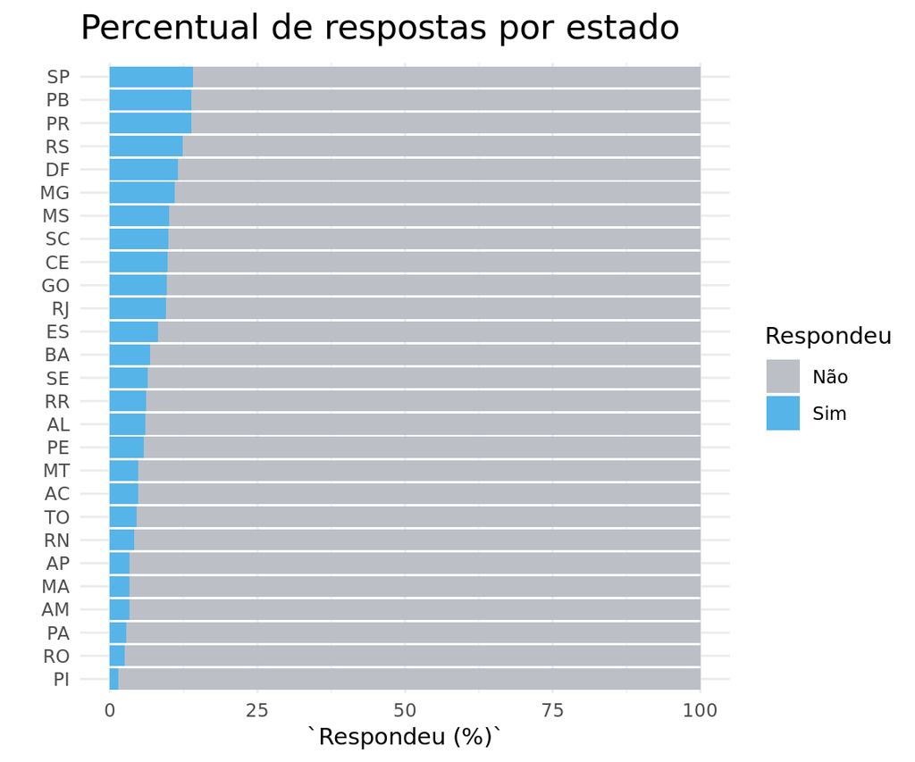

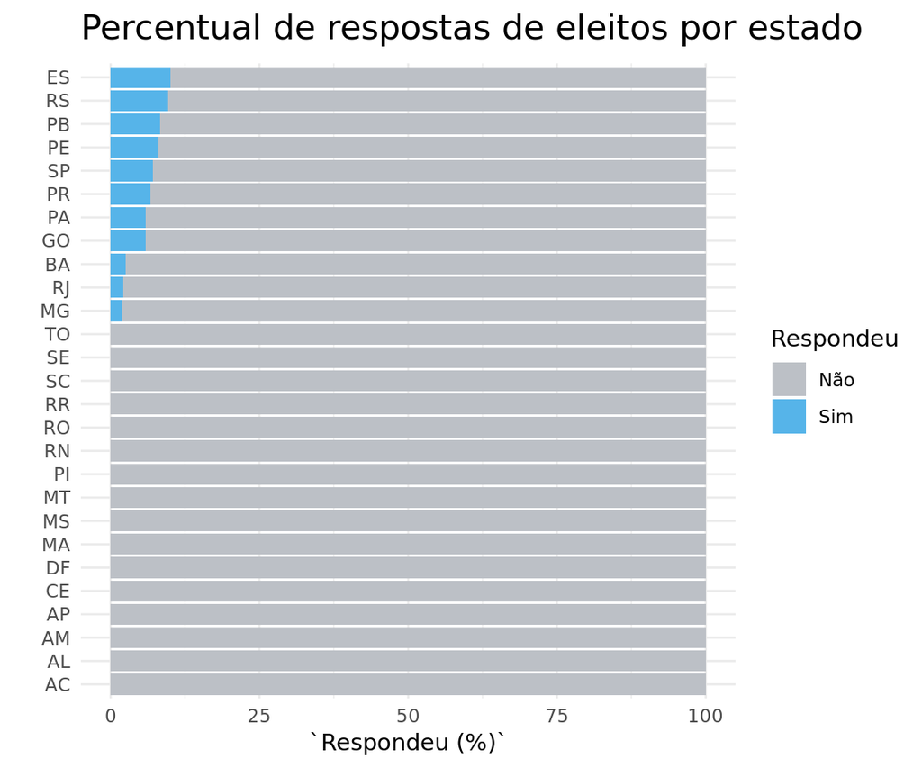

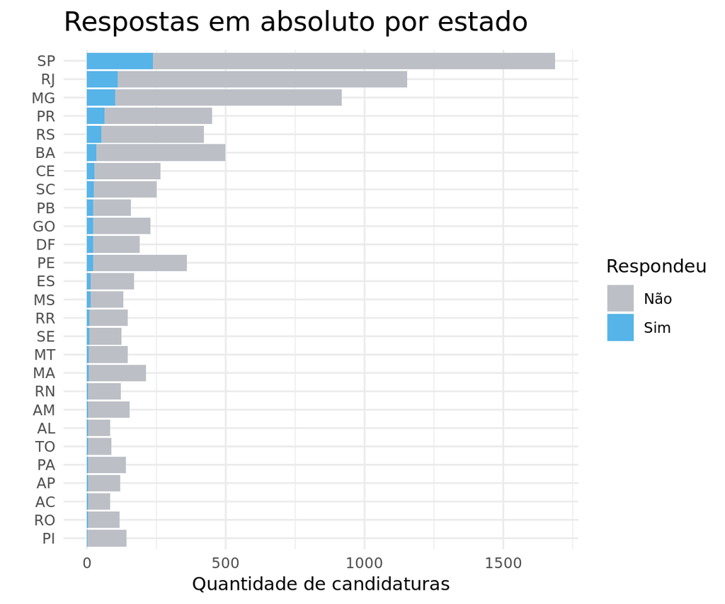

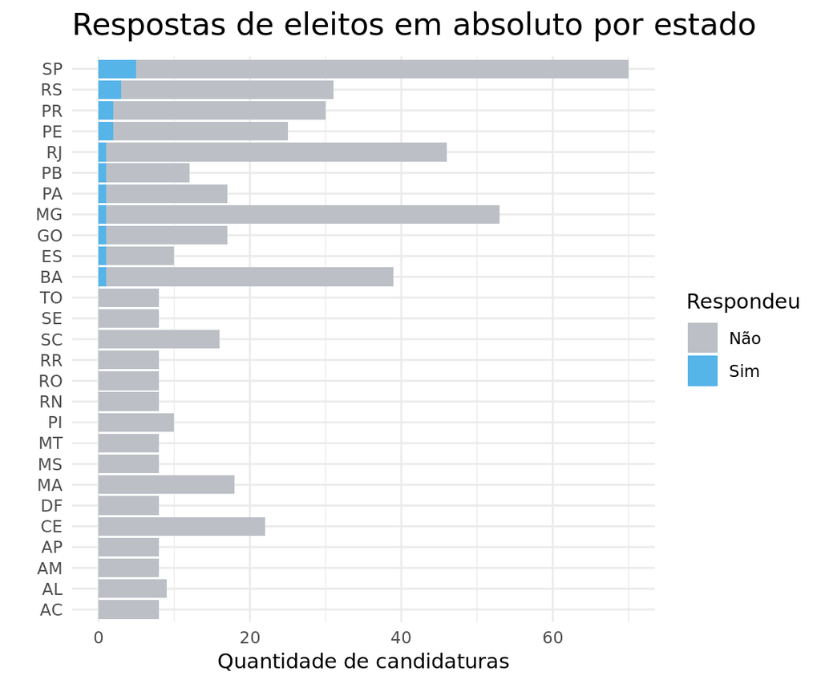

### Por partido

Sob a perspectiva de partido político, é visto que os partidos considerados menores, em geral, aderiram mais à Voz Ativa do que os tradicionalmente dominantes da câmara como o PSDB, MDB e PT, sendo esse uma exceção, pois teve uma porcentagem expressiva de respostas ao compará-lo aos outros.

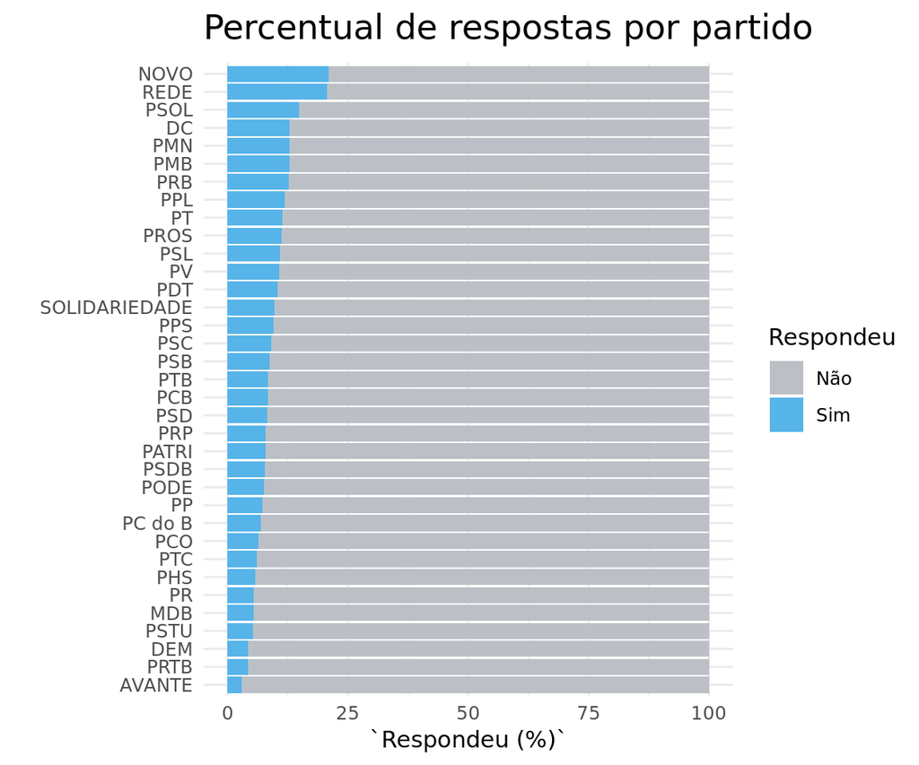

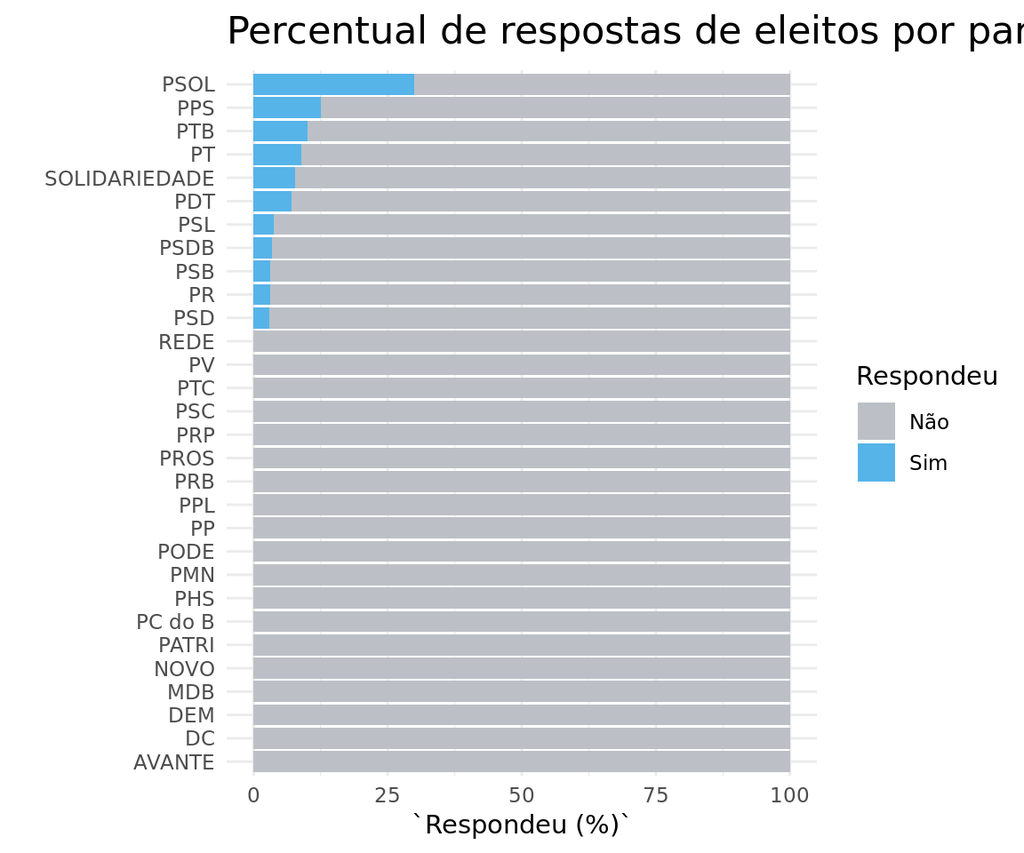

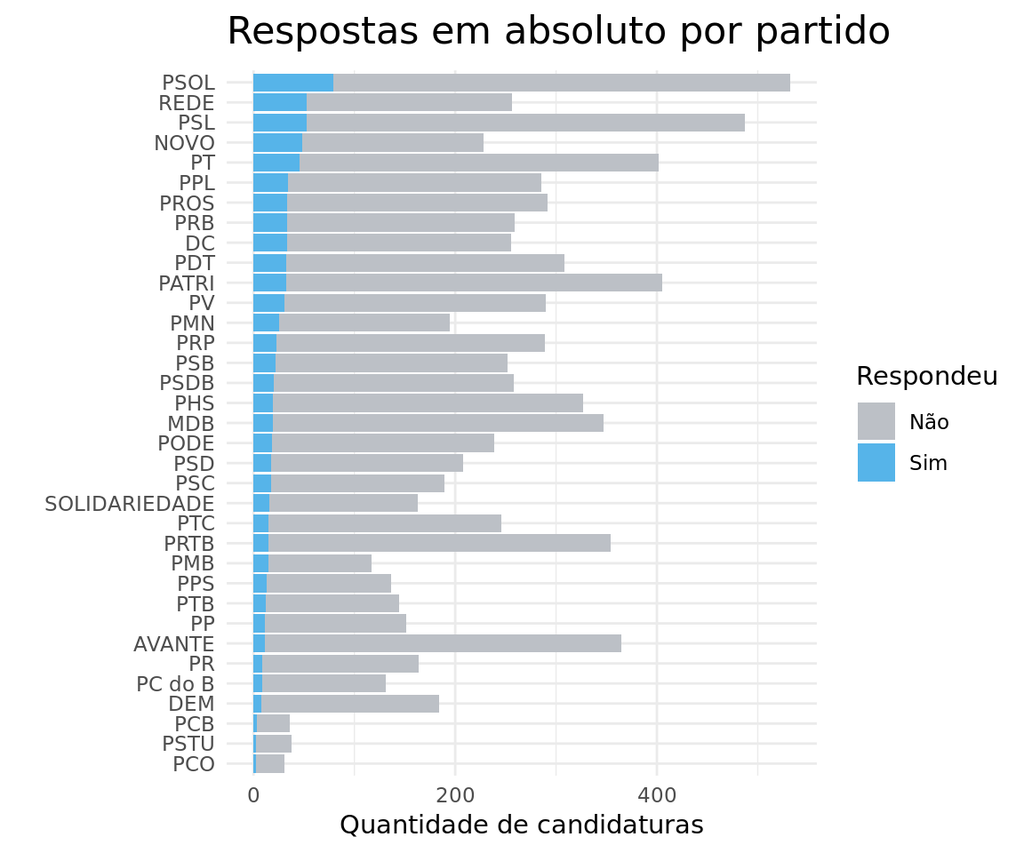

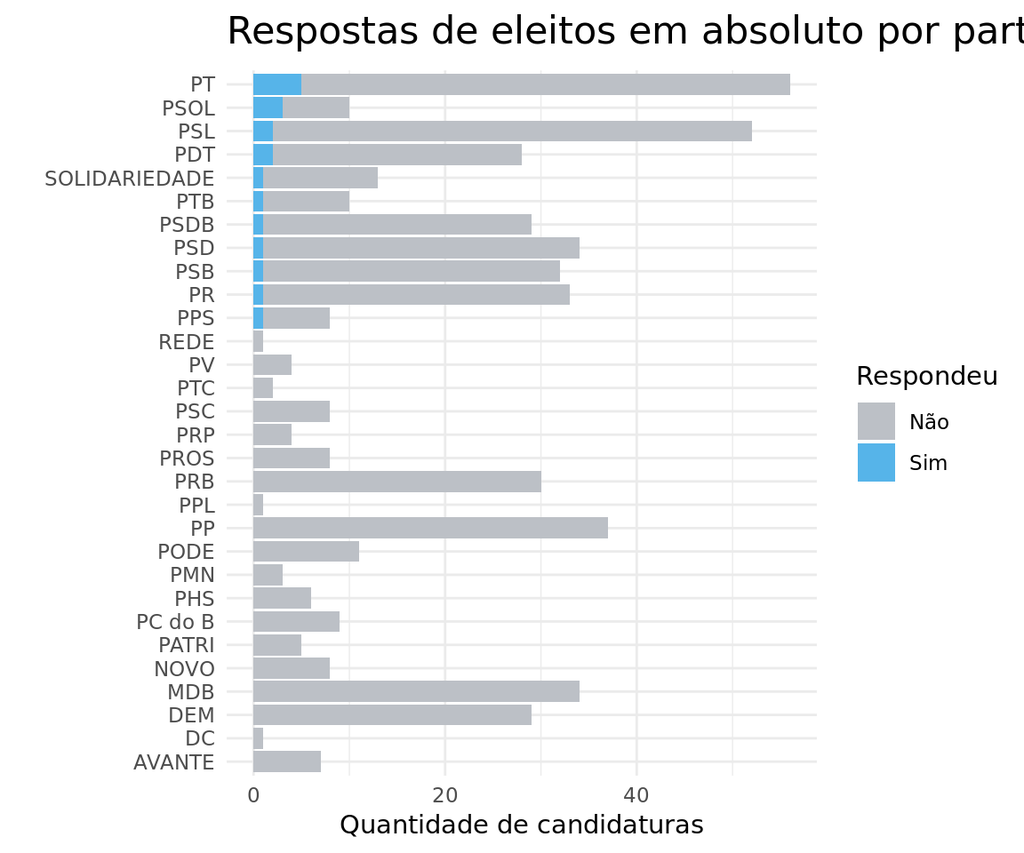

### Relação partidos e estados na Voz Ativa

A participação dos partidos nas eleições e como utilizaram a Voz Ativa em cada estado é observável abaixo. Em suma, os partidos com mais candidatos em um estado tem uma porcentagem baixa de adesão à plataforma. Há uma reafirmação da análise acima que indicou o NOVO, a REDE e o PSOL como os partidos mais presentes na Voz Ativa.

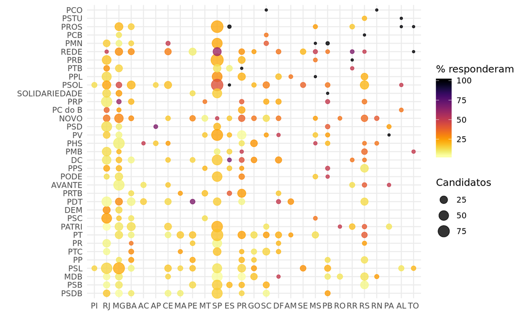

# Analisando os dados gerados pelo Google Analytics

### Quantidade de usuários por região

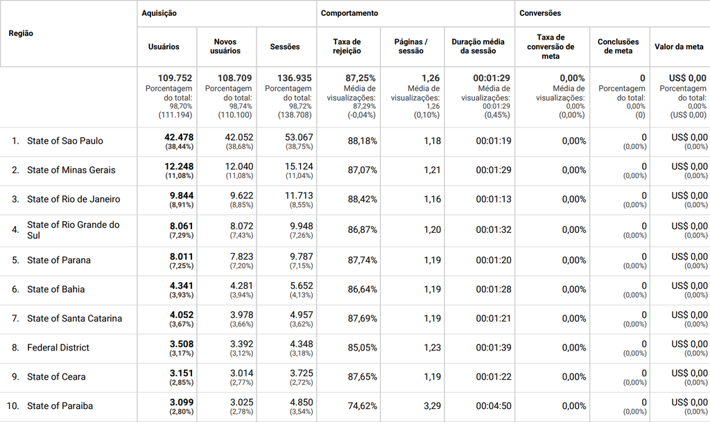

### Quantidade de visualizações da página

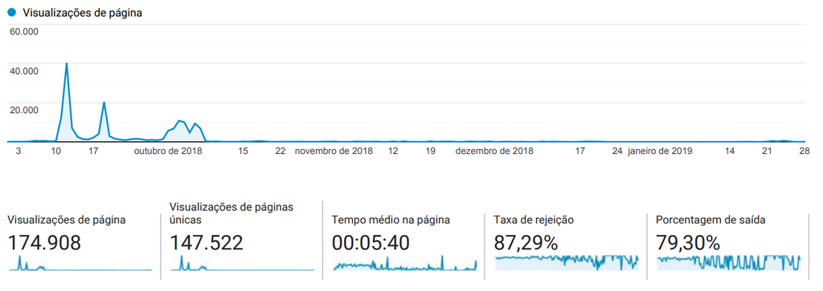

### Quantidade de usuários (visão geral)

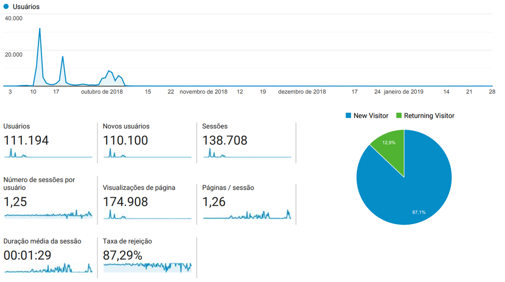

### Tempo de permanência na página

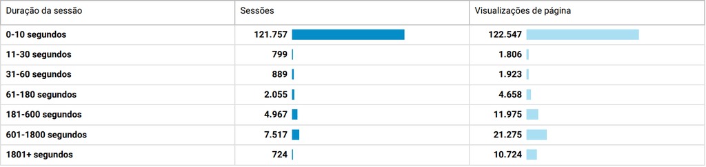

### Canais de acesso

Os gráficos abaixo informam por quais canais de acesso o vozativa.org foi visitado, podemos observar que redes sociais como o facebook foram o maior canal de acesso utilizado.

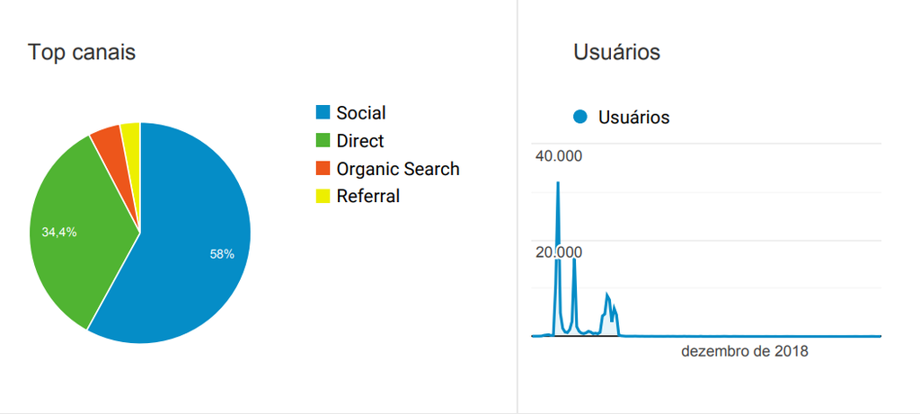

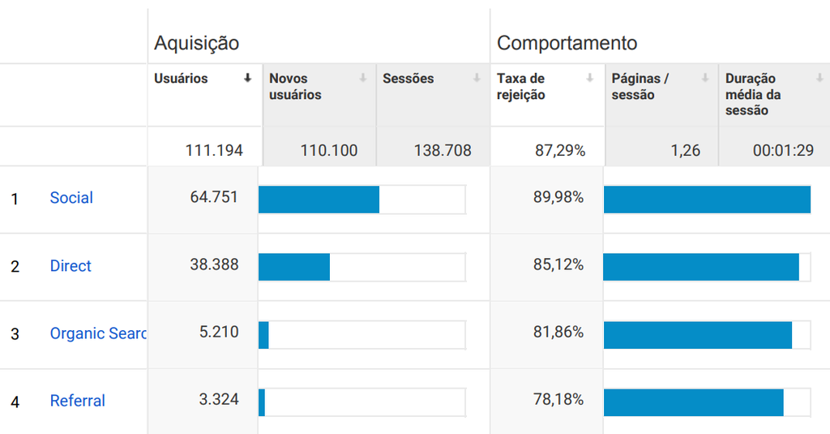